# Buck Converter: CCM

The buck converter given below is switched at $20\,$kHz and at a duty ratio of 0.5 with a load resistance of $1\,\Omega$. The input voltage to the buck converter is $10\,$V. The inductor is $100\,\mu$H with an ESR of $100\,$m$\Omega$, and the output capacitator is $1000\,\mu$F. The on-state resistance of the switch $S$ is $25\,$m$\Omega$, and the on-state drop across the diode is $0.8\,$V.

Evaluate the following quantities:

1. output voltage
2. average input current
3. output power
4. efficiency
5. average power dissipated in the switch, diode, and inductor

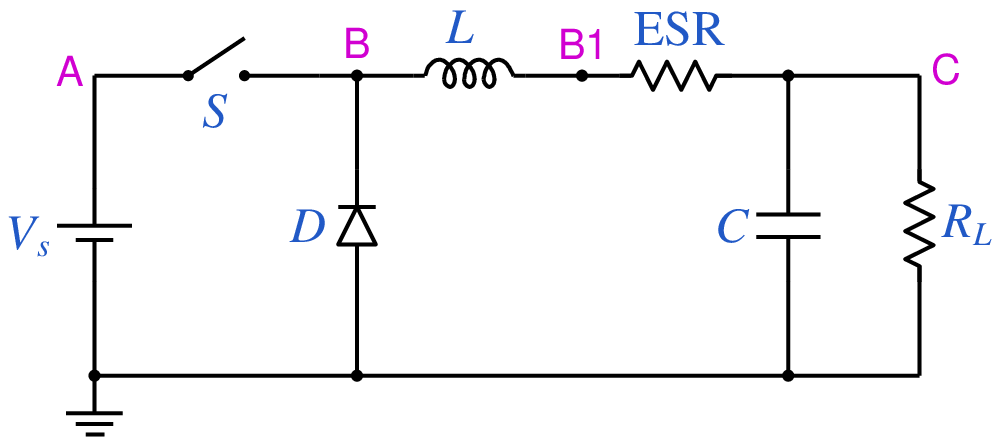

```python
from IPython.display import Image
Image(filename =r'buck_ccm_2_fig_1.png', width=350)
```

```python
# run this cell to view the circuit file.
%pycat buck_ccm_2_orig.in
```

We now replace the strings such as \$Vin, \$L, with the values of our choice by running the python script given below. It takes an existing circuit file `buck_ccm_2_orig.in` and produces a new circuit file `buck_ccm_2.in`, after replacing \$Vin, \$L, etc. with values of our choice.

```python
import gseim_calc as calc
s_Vin = '10'
s_L = '100u'
s_ESR = '100m'
s_R_sw = '25m'
s_V_D = '0.8'
s_R_load = '1'
s_f_hz = '20k'
s_D = '0.5'

l = [
  ('$Vin', s_Vin),
  ('$L', s_L),
  ('$ESR', s_ESR),
  ('$R_load', s_R_load),
  ('$V_D', s_V_D),
  ('$R_sw', s_R_sw),
  ('$f_hz', s_f_hz),
  ('$D', s_D)
]
calc.replace_strings_1("buck_ccm_2_orig.in", "buck_ccm_2.in", l)
print('buck_ccm_2.in is ready for execution')
```

```
buck_ccm_2.in is ready for execution
```

**Execute the following cell to run GSEIM on buck_ccm_2.in.**

```python
import os
import dos_unix
# uncomment for windows:
#dos_unix.d2u("buck_ccm_2.in")
os.system('run_gseim buck_ccm_2.in')
```

```
Circuit: filename = buck_ccm_2.in
main: calling solve_sss
solve_sss starting: sss_n_st: 2
solve_sss_ex: sss_iter_newton=0, rhs_sss_norm=2.9578e+00, sss_period_1_compute=1.0000e-04
solve_sss_ex: sss_iter_newton=1, rhs_sss_norm=7.6338e-13, sss_period_1_compute=1.0000e-04
solve_sss_ex: sss_iter_newton=2, rhs_sss_norm=1.5387e-14, sss_period_1_compute=1.0000e-04
solve_sss_ex: sss_iter_newton=3, rhs_sss_norm=6.2805e-16, sss_period_1_compute=1.0000e-04
solve_sss_ex: calling sss_solve_trns_ex for one more trns step
Transient simulation starts...
i=0
i=1000
GSEIM: Program completed.
```

```
0
```

The circuit file (`buck_ccm_2.in`) is created in the same directory as that used for launching Jupyter notebook. The last step (i.e., running `GSEIM` on `buck_ccm_2.in`) creates two data files `buck_ccm_2.dat` and `buck_ccm_2_1.dat` in the same directory. We can now use the python code below to plot the various quantities of interest.

```
filename: buck_ccm_2.dat
average output voltage:  4.1329E+00
average input current:  2.0685E+00
```

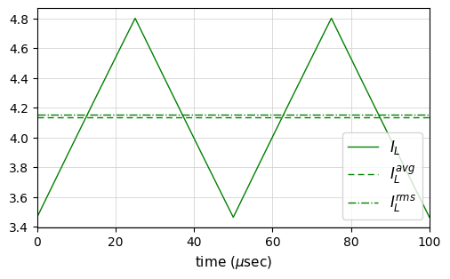

```python
import numpy as np
import matplotlib.pyplot as plt
import gseim_calc as calc
from setsize import set_size

slv = calc.slv("buck_ccm_2.in")

i_slv = 0
i_out = 0
filename = slv.l_filename_all[i_slv][i_out]
print('filename:', filename)
u = np.loadtxt(filename)
t1 = u[:, 0]
t = t1*1e6 # convert time to micro-seconds

IL = slv.get_array_double(i_slv,i_out,"IL",u)
IS = slv.get_array_double(i_slv,i_out,"IS",u)
ID = slv.get_array_double(i_slv,i_out,"ID",u)
IC = slv.get_array_double(i_slv,i_out,"IC",u)
v_in = slv.get_array_double(i_slv,i_out,"v_in",u)
v_out = slv.get_array_double(i_slv,i_out,"v_out",u)
clock = slv.get_array_double(i_slv,i_out,"clock",u)

# since we have stored two cycles, we need to divide the last time point
# by 2 to get the period:

T = t[-1]/2

l_IL = calc.avg_rms_3a(t, IL, 0.0, 2.0*T, 1.0e-3*T)
l_IS = calc.avg_rms_3a(t, IS, 0.0, 2.0*T, 1.0e-3*T)
l_ID = calc.avg_rms_3a(t, ID, 0.0, 2.0*T, 1.0e-3*T)
l_IC = calc.avg_rms_3a(t, IC, 0.0, 2.0*T, 1.0e-3*T)
l_v_out = calc.avg_rms_3a(t, v_out, 0.0, 2.0*T, 1.0e-3*T)

print('average output voltage:', "%11.4E"%l_v_out[0])
print('average input current:', "%11.4E"%l_IS[0])

color1='green'
color2='crimson'
color3='goldenrod'
color4='blue'

fig, ax = plt.subplots()
plt.subplots_adjust(wspace=0, hspace=0.0)

set_size(4, 2.5, ax)

plt.grid(color='#CCCCCC', linestyle='solid', linewidth=0.5)

# comment out lines for variables which should not be shown

ax.set_xlim(left=0.0, right=2.0*T)
ax.plot(t, IL, color=color1, linewidth=1.0, label="$I_L$")
ax.axhline(y=l_IL[0], color=color1, linewidth=1.0, label="$I_L^{avg}$", linestyle='--', dashes=(5,3))
ax.axhline(y=l_IL[1], color=color1, linewidth=1.0, label="$I_L^{rms}$", linestyle='-.')

plt.xlabel('time (' + r'$\mu$' + 'sec)', fontsize=11)

ax.legend(loc = 'lower right',frameon = True, fontsize = 10, title = None,
   markerfirst = True, markerscale = 1.0, labelspacing = 0.5, columnspacing = 2.0,
   prop = {'size' : 12},)

plt.tight_layout()
plt.show()
```

```
filename: buck_ccm_2_1.dat
average power (VS):  2.0685E+01
average power (ESR):  1.7230E+00
average power (switch):  2.1578E-01
average power (diode):  1.6602E+00
average power (load):  1.7081E+01
efficiency:  8.2578E-01
```

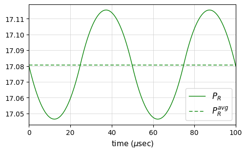

```python
import numpy as np
import matplotlib.pyplot as plt
import gseim_calc as calc
from setsize import set_size

slv = calc.slv("buck_ccm_2.in")

i_slv = 0
i_out = 1
filename = slv.l_filename_all[i_slv][i_out]
print('filename:', filename)
u = np.loadtxt(filename)
t1 = u[:, 0]
t = t1*1e6 # convert time to micro-seconds

P_VS = slv.get_array_double(i_slv,i_out,"P_VS",u)
P_ESR = slv.get_array_double(i_slv,i_out,"P_ESR",u)
P_S = slv.get_array_double(i_slv,i_out,"P_S",u)
P_D = slv.get_array_double(i_slv,i_out,"P_D",u)
P_R = slv.get_array_double(i_slv,i_out,"P_R",u)

# since we have stored two cycles, we need to divide the last time point
# by 2 to get the period:

T = t[-1]/2

l_P_VS = calc.avg_rms_3a(t, P_VS, 0.0, 2.0*T, 1.0e-3*T)
l_P_ESR = calc.avg_rms_3a(t, P_ESR, 0.0, 2.0*T, 1.0e-3*T)
l_P_S = calc.avg_rms_3a(t, P_S, 0.0, 2.0*T, 1.0e-3*T)
l_P_D = calc.avg_rms_3a(t, P_D, 0.0, 2.0*T, 1.0e-3*T)
l_P_R = calc.avg_rms_3a(t, P_R, 0.0, 2.0*T, 1.0e-3*T)

print('average power (VS):', "%11.4E"%l_P_VS[0])
print('average power (ESR):', "%11.4E"%l_P_ESR[0])
print('average power (switch):', "%11.4E"%l_P_S[0])
print('average power (diode):', "%11.4E"%l_P_D[0])
print('average power (load):', "%11.4E"%l_P_R[0])

print('efficiency:', "%11.4E"%(l_P_R[0]/l_P_VS[0]))

color1='green'
color2='crimson'
color3='goldenrod'
color4='blue'

fig, ax = plt.subplots()
plt.subplots_adjust(wspace=0, hspace=0.0)

set_size(4, 2.5, ax)

plt.grid(color='#CCCCCC', linestyle='solid', linewidth=0.5)

ax.set_xlim(left=0.0, right=2.0*T)
ax.plot(t, P_R, color=color1, linewidth=1.0, label="$P_{R}$")
ax.axhline(y=l_P_R[0], color=color1, linewidth=1.0, label="$P_{R}^{avg}$", linestyle='--', dashes=(5,3))

plt.xlabel('time (' + r'$\mu$' + 'sec)', fontsize=11)

ax.legend(loc = 'lower right',frameon = True, fontsize = 10, title = None,
   markerfirst = True, markerscale = 1.0, labelspacing = 0.5, columnspacing = 2.0,
   prop = {'size' : 12},)

plt.tight_layout()
plt.show()
```

This notebook was contributed by **Prof. Nakul Narayanan K**, Govt. Engineering College, Thrissur. He may be contacted at nakul@gectcr.ac.in.